# Early Earth — figures and the story they tell

**What we want readers to see:** short quenches change observed connectivity; large structural variety coexists with an abundant core of small, recurrent fragments. The manuscript opens with energy history and alanine geometry; this notebook develops the quench and structural-coverage evidence that follows.

**Advisor reading path:** quench response → the same atoms → variety versus abundance → rare versus recurrent. Stop after those four figures for a short review. Additional candidates are available for figure selection.

A **fragment** is a connected component, including isolated atoms; sizes include H. A **distinct emitted string** is a representation of connectivity, not a verified chemical species. All figures are working candidates awaiting author/advisor selection.

## 1. How does a short quench change fragment size? — F12/F13

**Point:** mean size rises in 3,439 of 3,521 pairs; the largest component rises in 2,812. Mean size is total atoms divided by component count; largest size is an individual-component maximum. The lower panels show paired changes.

**Scope:** every point is one of 3,521 independent 25-fs endpoints from the 22.8M-atom system. The dotted line marks the restart; endpoints do not form a cooling trajectory.

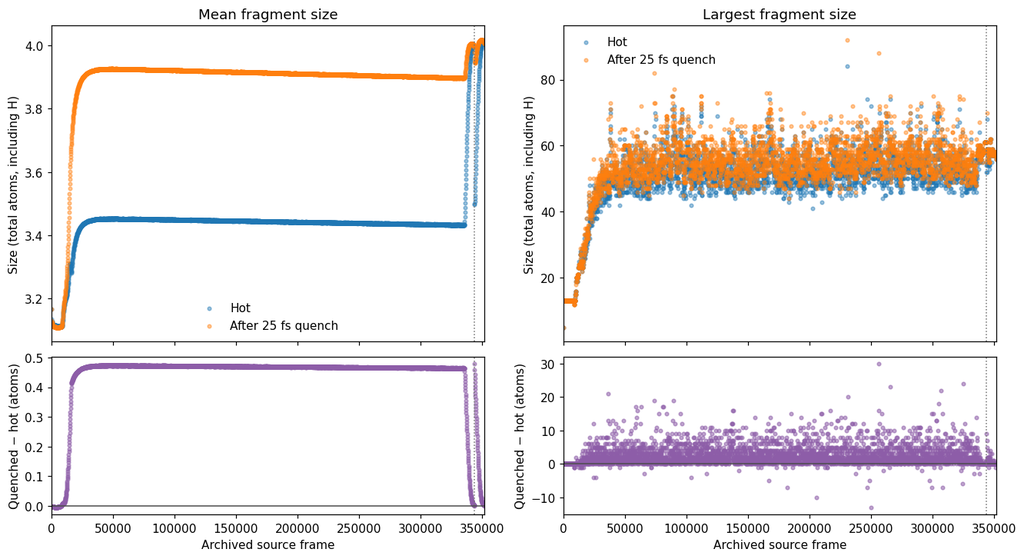

## 2. What does a connectivity change look like? — F14

**Point:** the same ten atom IDs go from a nine-atom component plus isolated H to one ten-atom component. Purple highlights the added C–H cutoff connection; its true 3D distance changes from 1.3150 to 1.0929 Å.

**Scope:** selected logical frame 447 (source frame 44,700), rigidly aligned without reflection and shown on a common projection/scale. This illustrates connectivity, without assigning a reaction mechanism or electronic state.

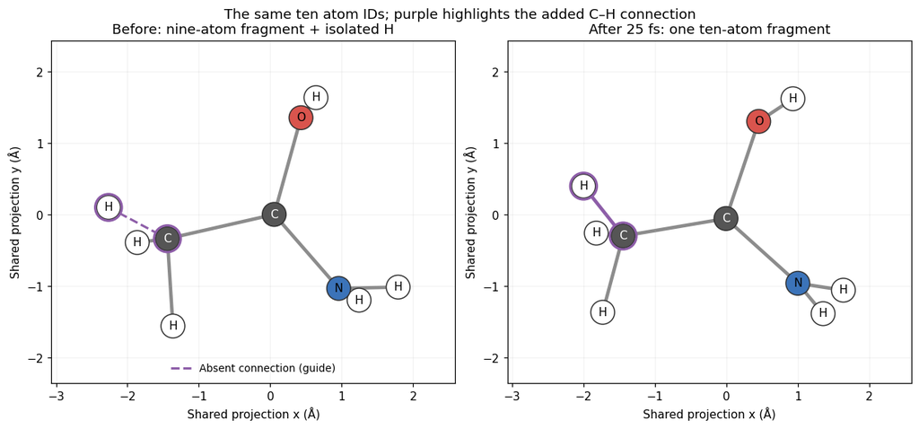

## 3. Which sizes supply variety, and which supply abundance? — F17

**Point:** median size is 23 atoms when each distinct string counts once, but 3 atoms when each fragment occurrence counts; 90% of occurrences have at most 5 atoms.

**Scope:** the 10,259,647-string hot/quenched union and the two state-specific occurrence totals are normalized separately. Repeated sampled occurrences do not measure yield or track individual molecules. F16's unweighted histogram is below.

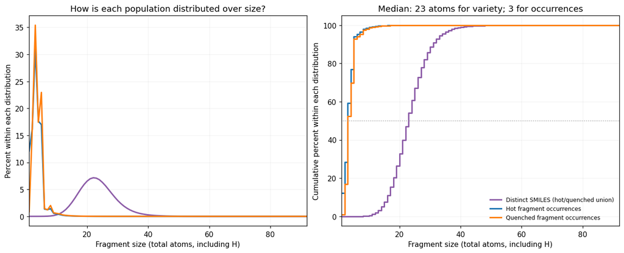

## 4. Is structural variety repeatedly observed? — F18

**Point:** 74.48% of carbon-containing strings appear in one sampled frame pair; strings seen in at least 1,000 pairs supply over 99.5% of carbon-fragment occurrences.

**Scope:** recurrence counts presence in either state across 3,521 sampled pairs. Each bar series has its own carbon-containing denominator. Recurrence is sampled presence, not continuous lifetime or stability.

**Pause for advisor review:** which of these four points deserves a main-text panel, and which belongs in supporting information?

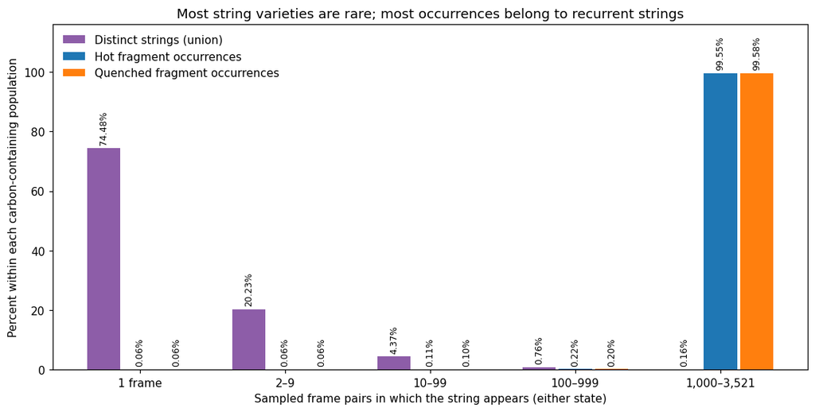

## Additional figure candidates

Use these when they add a distinct point to the chosen argument. They are excluded from the short advisor HTML by default. Formula browsing, clusters, 3D rotation and the withdrawn F15 chemical-group census live in exploration.

### Which size has the most distinct strings? — F16

The unweighted union counts each string once, including H. Mode: 22 atoms (733,298 strings); range: 1–92. This answers a variety question; F17 supplies abundance context.

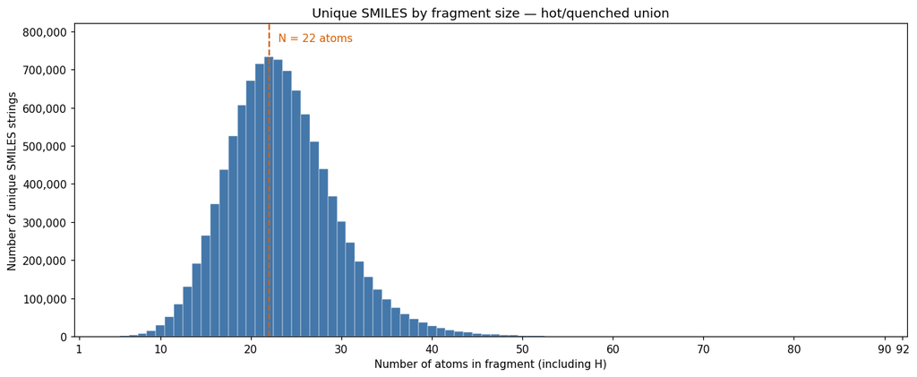

```
Unique strings counted: 10,259,647
Most represented size(s): [22] atoms; 733,298 unique strings each
```

### Which compositions and architectures supply variety? — F18

Each series is normalized separately. Composition includes the full union; architecture is restricted to carbon-containing strings. A heavy atom is C, N or O; an H-mediated connection can leave the heavy-only skeleton disconnected. These are observed topology classes, not electronic chemical families.

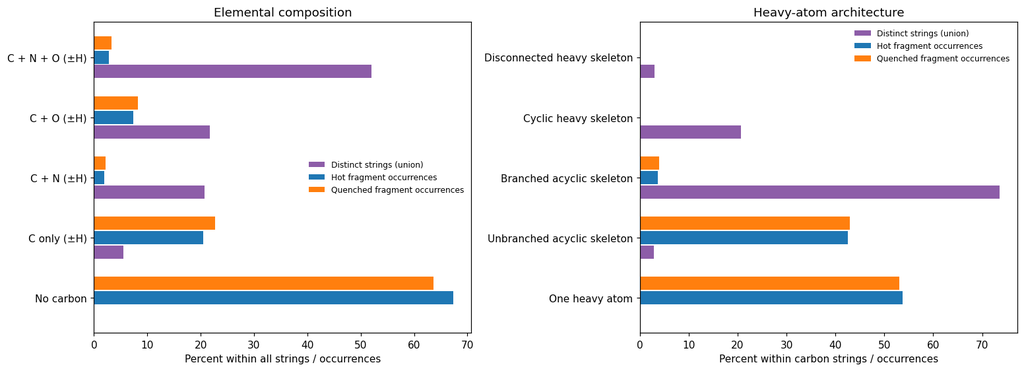

### Which local connections differ between states? — F18

Motifs count explicit element neighbors and coordination, including H; they do not assign functional groups. Left: distinct carbon-string prevalence with a common size distribution over shared sizes. Right: state-specific carbon-occurrence weights. Motifs overlap; percentages do not sum to 100. Definitions and weights.

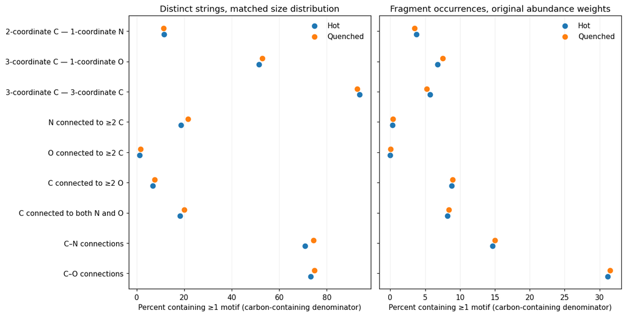

### How does counting hydrogen-only fragments affect mean size? — F19

**Point:** hot and quenched sizes are much closer when hydrogen-only fragments are excluded. Both figures use the same axes; **blue = hot, orange = quenched**.

- **Including H-only:** C+N+O atoms / all original fragments; H-only fragments contribute zero.
- **Excluding H-only:** C+N+O atoms / fragments containing at least one non-H atom.

All 3,521 original-run/independent 25-fs quench pairs. Frame numbers follow the archived run (sampled every 100 frames); dotted line marks its restart. Fragment membership and H bridges stay intact. Quenched points are independent endpoints.

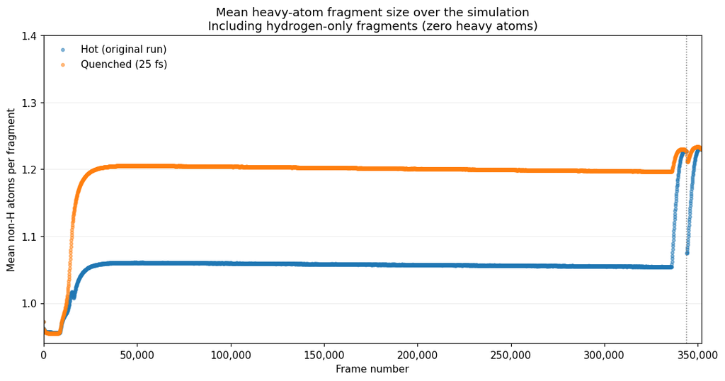

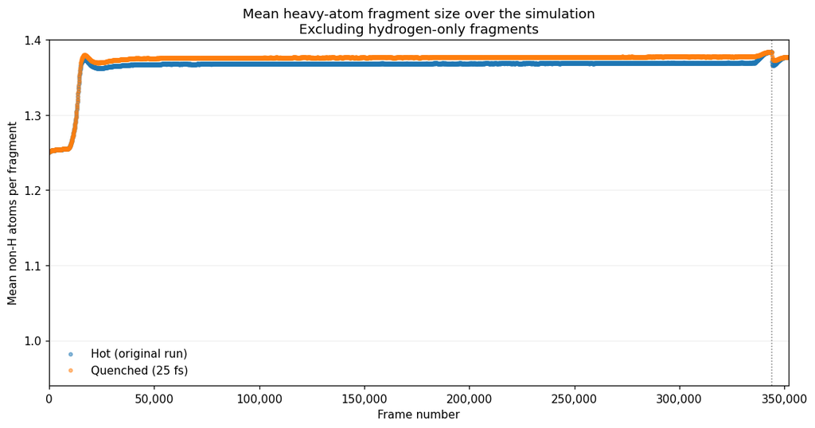

### What changes after excluding starting formulas and single atoms? — F19

**Point:** the retained fragment population averages **2.10 hot / 2.53 quenched heavy atoms**. Counting the residual H-only fragments makes almost no difference because the filters already remove H and H2.

Remove H2, H2O, CO, NH3 and CH4 **compositions**, plus fragments with **one total atom**. OH, NH2 and CH3 compositions remain eligible. Formula exclusions also remove reformed matching compositions; they do not identify atom origins. Both means use occurrence counts and the same axes. The initial frame has no eligible fragments: its mean is undefined and omitted. Original connectivity stays intact. Historical averaging audit.

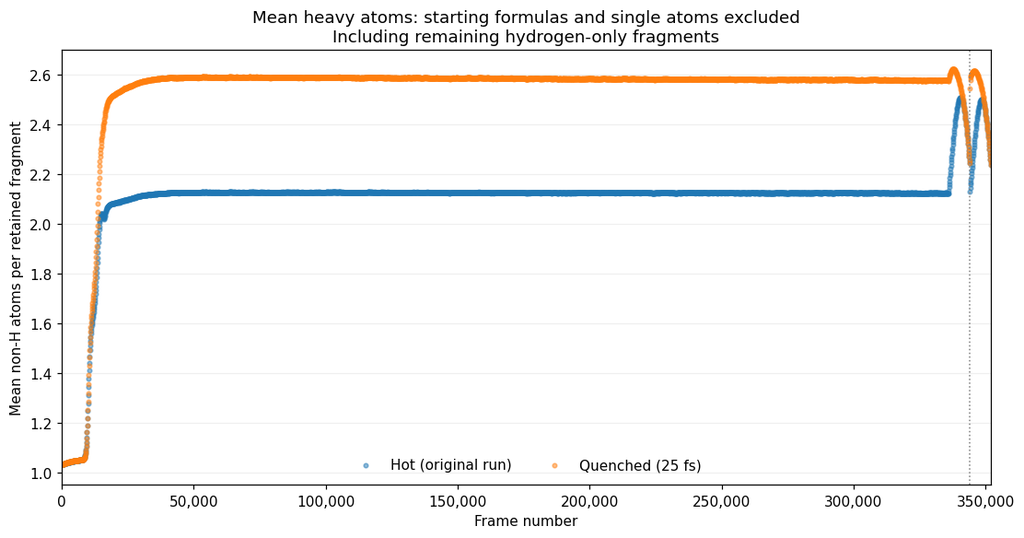

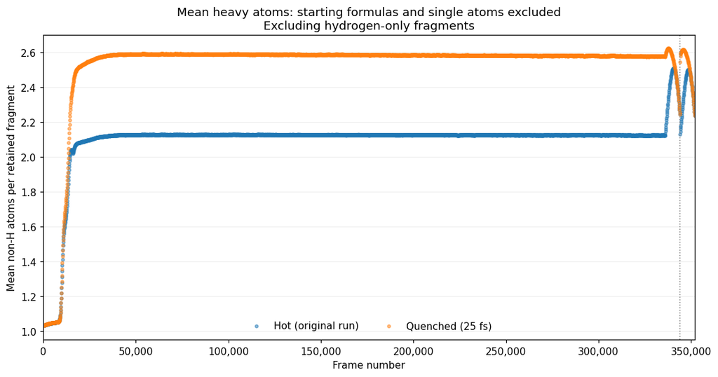

### How much of the size change involves non-hydrogen atoms? — F19

**Point:** the mean over every fragment rises **12.56%**, while the mean among fragments containing non-H atoms rises **0.55%**. Hydrogen-only fragments contribute zeros to the first mean; their mean per-frame share falls from **22.39% to 13.15%**. Largest non-H counts are 42 hot / 43 quenched; maxima usually stay unchanged.

Heavy = C + N + O here. **Keep original fragment membership**, even when H bridges heavy atoms; counting H as zero does not delete it from connectivity. Dotted line: restart. All 3,521 production pairs; original-DCD hot and independent quenched endpoints. The canonical-coordinate analogue of F12 is available in exploration.

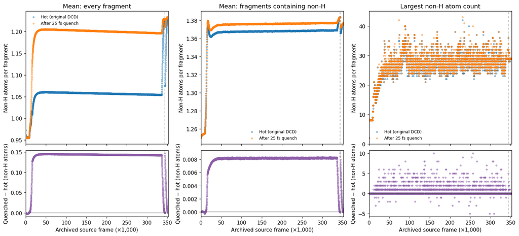

### Do heavy-atom sizes tell the same variety-versus-abundance story? — F20

**Point:** median size is **11 non-H atoms** for distinct strings, but **one** for repeated fragment occurrences. Each series has its own denominator. Default: exclude H-only fragments from all three distributions; set `INCLUDE_H_ONLY = True` to retain their zero-size bin. H-only fragments supply 22.44% / 13.25% of pooled hot/quenched occurrences. These pooled shares differ from mean per-frame shares.

The complete union includes non-carbon heavy fragments. Strings are representations, not confirmed species; occurrences are repeated observations, not yields.

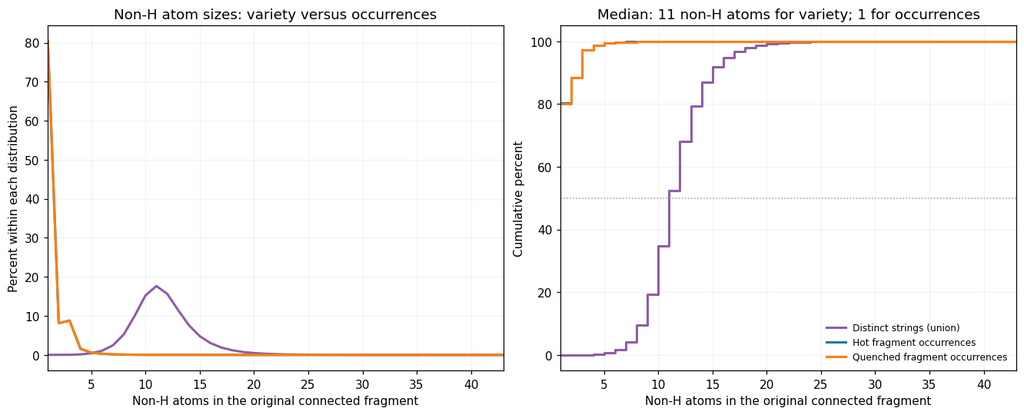